# Spam Prediction in the Spam (kernlab) Dataset

JaysonSunshine

02/19/2015

```r
library(kernlab)
set.seed(12345)
data(spam)
```

First, we look at the spam dataset:

```r
head(spam)
```

```
##   make address  all num3d  our over remove internet order mail receive
## 1 0.00    0.64 0.64     0 0.32 0.00   0.00     0.00  0.00 0.00    0.00
## 2 0.21    0.28 0.50     0 0.14 0.28   0.21     0.07  0.00 0.94    0.21
## 3 0.06    0.00 0.71     0 1.23 0.19   0.19     0.12  0.64 0.25    0.38
## 4 0.00    0.00 0.00     0 0.63 0.00   0.31     0.63  0.31 0.63    0.31
## 5 0.00    0.00 0.00     0 0.63 0.00   0.31     0.63  0.31 0.63    0.31
## 6 0.00    0.00 0.00     0 1.85 0.00   0.00     1.85  0.00 0.00    0.00
##   will people report addresses free business email  you credit your font
## 1 0.64   0.00   0.00      0.00 0.32     0.00  1.29 1.93   0.00 0.96    0
## 2 0.79   0.65   0.21      0.14 0.14     0.07  0.28 3.47   0.00 1.59    0
## 3 0.45   0.12   0.00      1.75 0.06     0.06  1.03 1.36   0.32 0.51    0
## 4 0.31   0.31   0.00      0.00 0.31     0.00  0.00 3.18   0.00 0.31    0
## 5 0.31   0.31   0.00      0.00 0.31     0.00  0.00 3.18   0.00 0.31    0
## 6 0.00   0.00   0.00      0.00 0.00     0.00  0.00 0.00   0.00 0.00    0
##   num000 money hp hpl george num650 lab labs telnet num857 data num415
```

[output cut: 34 more lines]

The spamPredictor function uses only the ‘your’ feature from the spam dataset to predict spam v. non-spam. spamPredictor finds the optimal threshold to maximize accuracy using only this feature

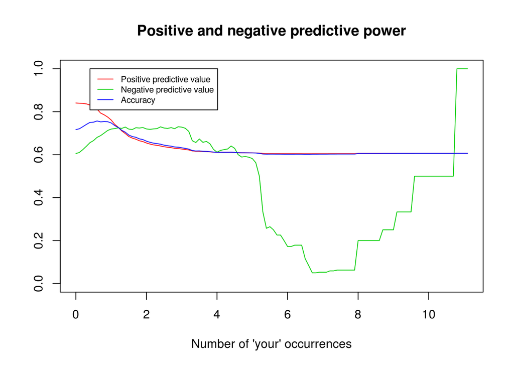

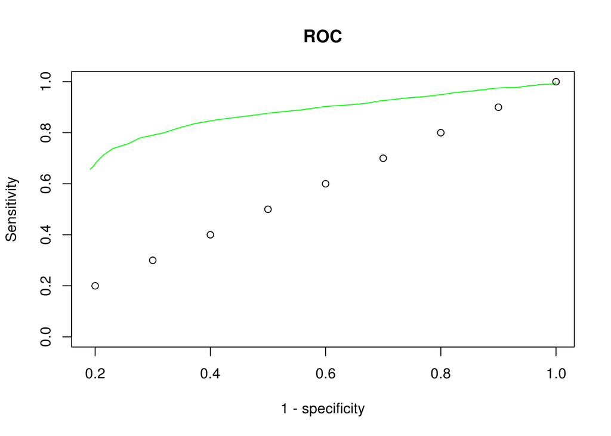

```r
spamPredictor <- function(spam){
  vals = seq(0,11.1,by=0.1)
  optimal_pos = 0
  optimal_neg = 0
  optimal_acc = 0
  pos = 0
  neg = 0
  acc_loc = 0
  ns_vals = double()
  ns_sensitivity = double()
  ns_specificity = double()
  accuracy = double()
  s_vals = double()
  steps = double()
  for(i in vals){
    prediction <- ifelse(spam$your > i, "spam", "nonspam")
    x <- table(prediction, spam$type)/length(spam$type)
    ns <- x[1,1] / (x[1,1] + x[1,2])
    ns_sens <- x[1,1] / (x[1,1] + x[2,1])
    ns_spec <- x[2,2] / (x[1,2] + x[2,2])
    ns_vals <- c(ns_vals, ns)
    ns_sensitivity <-c(ns_sensitivity, ns_sens)
    ns_specificity <-c(ns_specificity, ns_spec)
    steps = c(steps, i)
    if(ns > pos){
      pos = ns
      optimal_pos = i
    }
    s <- x[2,2] / (x[2,1] + x[2,2])
    if(s > neg){
      neg = s
      optimal_neg = i
    }
    acc = (x[1,1] + x[2,2]) / sum(x)
    if(acc > optimal_acc){
      optimal_acc = acc
      optimal_loc = i
    }
    s_vals <- c(s_vals, s)
    accuracy <- c(accuracy,acc)
  }
  #old.par <- par(mfrow=c(2, 1))
  #dev.new(width = 5, height = 4)
  plot(steps, ns_vals, xlab = "Number of 'your' occurrences",type='l',
       col=2, ylim = c(0,1), main = "Positive and negative predictive power", ylab="" )
  lines(steps, s_vals, col=3)
  lines(steps, accuracy, col=4)
  legend(0.4,1,c("Positive predictive value", "Negative predictive value", "Accuracy"), col=c(2,3,4), lty=c(1,1), cex =0.7)
  plot(1 - ns_specificity, ns_sensitivity, col="green", type='l', ylim = c(0,1),
       xlab = "1 - specificity", ylab = "Sensitivity", main = "ROC")
  points(steps, steps)
  #lines(steps, ns_specificity, col="orange")
  #par(old.par)
  z = list("optimal_pos_loc" = optimal_pos, "optimal_pos_val" = pos, "optimal_neg_loc" = optimal_neg, "optimal_neg_val" = neg, "optimal_acc_loc" = optimal_loc, "optimal_acc_val" =
             optimal_acc)
  return(z)
}
results = spamPredictor(spam)
```

```r
results
```

```
## $optimal_pos_loc
## [1] 0
##
## $optimal_pos_val
## [1] 0.8406795
##
## $optimal_neg_loc
## [1] 10.8
##
## $optimal_neg_val
## [1] 1
##
## $optimal_acc_loc
## [1] 0.6
##
## $optimal_acc_val
## [1] 0.7570093
```

The above analysis shows that for single variable analysis, using only the number of occurrences of ‘your’ in the email, we can achieve a spam v. non-spam accuracy of 75.7% by using a threshold value of 0.6.

Next, we use the caret package to explore several other more robust models in which all features of the spam dataset are used.

```r
library(caret)
#60% of our values are used for constructing the training set
inTrain <- createDataPartition(y=spam$type, p=0.6, list=FALSE)

training <-spam[inTrain,]
testing <- spam[-inTrain,]

suppressWarnings(modelFit_glm <- train(type ~., data=training, method="glm"))
modelFit_glm
```

```
## Generalized Linear Model
##
## 2761 samples
##   57 predictors
##    2 classes: 'nonspam', 'spam'
##
## No pre-processing
## Resampling: Bootstrapped (25 reps)
##
## Summary of sample sizes: 2761, 2761, 2761, 2761, 2761, 2761, ...
##
## Resampling results
##
##   Accuracy   Kappa      Accuracy SD  Kappa SD
##   0.9178637  0.8268386  0.02124111   0.0488519
##
##
```

```r
predictions <- predict(modelFit_glm, newdata=testing)
confusionMatrix(predictions, testing$type)
```

```
## Confusion Matrix and Statistics
##
##           Reference
## Prediction nonspam spam
##    nonspam    1058   81
##    spam         57  644
##
##                Accuracy : 0.925
##                  95% CI : (0.912, 0.9366)
##     No Information Rate : 0.606
##     P-Value [Acc > NIR] : < 2e-16
##
##                   Kappa : 0.842
##  Mcnemar's Test P-Value : 0.05024
##
##             Sensitivity : 0.9489
##             Specificity : 0.8883
##          Pos Pred Value : 0.9289
##          Neg Pred Value : 0.9187
##              Prevalence : 0.6060
##          Detection Rate : 0.5750
##    Detection Prevalence : 0.6190
##       Balanced Accuracy : 0.9186
##
##        'Positive' Class : nonspam
##
```

Using a generalized linear model with all features of spam dataset, we achieve an accuracy of 91.79% on the training set and 92.5% on the test set

[output not shown]

[output not shown]

Using stochastic gradient boosting, using all features of the spam dataset, we achieve an accuracy of 94.52% on the training set and 93.75% accuracy on the test set.

```r
suppressWarnings(modelFit_svm <- train(type ~., data=training, method="svmLinear"))
modelFit_svm
```

```
## Support Vector Machines with Linear Kernel
##
## 2761 samples
##   57 predictors
##    2 classes: 'nonspam', 'spam'
##
## No pre-processing
## Resampling: Bootstrapped (25 reps)
##
## Summary of sample sizes: 2761, 2761, 2761, 2761, 2761, 2761, ...
##
## Resampling results
##
##   Accuracy   Kappa      Accuracy SD  Kappa SD
##   0.9254654  0.8433606  0.005406397  0.01113216
##
## Tuning parameter 'C' was held constant at a value of 1
##
```

```r
predictions <- predict(modelFit_svm, newdata=testing)
confusionMatrix(predictions, testing$type)
```

```
## Confusion Matrix and Statistics
##
##           Reference
## Prediction nonspam spam
##    nonspam    1055   75
##    spam         60  650
##
##                Accuracy : 0.9266
##                  95% CI : (0.9138, 0.9381)
##     No Information Rate : 0.606
##     P-Value [Acc > NIR] : <2e-16
##
##                   Kappa : 0.8458
##  Mcnemar's Test P-Value : 0.2282
##
##             Sensitivity : 0.9462
##             Specificity : 0.8966
##          Pos Pred Value : 0.9336
##          Neg Pred Value : 0.9155
##              Prevalence : 0.6060
##          Detection Rate : 0.5734
##    Detection Prevalence : 0.6141
##       Balanced Accuracy : 0.9214
##
##        'Positive' Class : nonspam
##
```

A support vector machine with linear kernel provides 92.55% accuracy on training set and 92.66% accuracy on test set.

We achieve accuracy of over 91.9% with a random forest. (results not shown)

```r
modelFit_rpart <- train(type ~., data=training, method="rpart")
modelFit_rpart
```

```
## CART
##
## 2761 samples
##   57 predictors
##    2 classes: 'nonspam', 'spam'
##
## No pre-processing
## Resampling: Bootstrapped (25 reps)
##
## Summary of sample sizes: 2761, 2761, 2761, 2761, 2761, 2761, ...
##
## Resampling results across tuning parameters:
##
##   cp          Accuracy   Kappa      Accuracy SD  Kappa SD
##   0.06985294  0.8215504  0.6221559  0.02249869   0.04696270
##   0.07444853  0.8168455  0.6142914  0.02407778   0.04864253
##   0.48437500  0.7023295  0.3051601  0.09515024   0.27662878
##
## Accuracy was used to select the optimal model using  the largest value.
## The final value used for the model was cp = 0.06985294.
```

```r
predictions <- predict(modelFit_rpart, newdata=testing)
confusionMatrix(predictions, testing$type)
```

```
## Confusion Matrix and Statistics
##
##           Reference
## Prediction nonspam spam
##    nonspam    1041  267
##    spam         74  458
##
##                Accuracy : 0.8147
##                  95% CI : (0.7962, 0.8322)
##     No Information Rate : 0.606
##     P-Value [Acc > NIR] : < 2.2e-16
##
##                   Kappa : 0.593
##  Mcnemar's Test P-Value : < 2.2e-16
##
##             Sensitivity : 0.9336
##             Specificity : 0.6317
##          Pos Pred Value : 0.7959
##          Neg Pred Value : 0.8609
##              Prevalence : 0.6060
##          Detection Rate : 0.5658
##    Detection Prevalence : 0.7109
##       Balanced Accuracy : 0.7827
##
##        'Positive' Class : nonspam
##
```

We achieve an accuracy of 82.16% on the training set using classification and regression trees (CART), and 81.47% accurac on the test set.

```r
capture.output(modelFit_nnet <- train(type ~., data=training, method="nnet"), file='NUL')
modelFit_nnet
```

```
## Neural Network
##
## 2761 samples
##   57 predictors
##    2 classes: 'nonspam', 'spam'
##
## No pre-processing
## Resampling: Bootstrapped (25 reps)
##
## Summary of sample sizes: 2761, 2761, 2761, 2761, 2761, 2761, ...
##
## Resampling results across tuning parameters:
##
##   size  decay  Accuracy   Kappa      Accuracy SD  Kappa SD
##   1     0e+00  0.8906584  0.7655596  0.066231176  0.17241292
##   1     1e-04  0.8393926  0.6243925  0.132960235  0.35363145
##   1     1e-01  0.9272355  0.8482397  0.008496003  0.01746492
##   3     0e+00  0.9225580  0.8385038  0.024232270  0.04805599
##   3     1e-04  0.9243352  0.8418648  0.011609575  0.02446403
##   3     1e-01  0.9313034  0.8562914  0.010084010  0.02100872
##   5     0e+00  0.9312791  0.8562088  0.008149483  0.01713756
##   5     1e-04  0.9295296  0.8525310  0.008558600  0.01772226
##   5     1e-01  0.9337628  0.8613387  0.008709115  0.01833183
##
## Accuracy was used to select the optimal model using  the largest value.
## The final values used for the model were size = 5 and decay = 0.1.
```

```r
predictions <- predict(modelFit_nnet, newdata=testing)
confusionMatrix(predictions, testing$type)
```

```
## Confusion Matrix and Statistics
##
##           Reference
## Prediction nonspam spam
##    nonspam    1061   55
##    spam         54  670
##
##                Accuracy : 0.9408
##                  95% CI : (0.929, 0.9511)
##     No Information Rate : 0.606
##     P-Value [Acc > NIR] : <2e-16
##
##                   Kappa : 0.8759
##  Mcnemar's Test P-Value : 1
##
##             Sensitivity : 0.9516
##             Specificity : 0.9241
##          Pos Pred Value : 0.9507
##          Neg Pred Value : 0.9254
##              Prevalence : 0.6060
##          Detection Rate : 0.5766
##    Detection Prevalence : 0.6065
##       Balanced Accuracy : 0.9379
##
##        'Positive' Class : nonspam
##
```

Using a neural network with the default of 100 iterations we get 93.37% accuracy on the training set, and 94.08% on the test set.